# COVID FINAL PROJECT

#### By Chi Nam Tran, Aileen Zaman, Nathacia Nathacia, Sophia Van Den Ende, Shruti Lakhani and Justin Vu

## COVID-19 Background

Since December 2019, COVID-19 disease (commonly labelled as the coronavirus or covid)

[figure not shown]

*Illustration of Covid-19

## Introduction & Purpose of Project

Our group aims to understand better of covid-19 and it's affect on the United States in the different states. We'll look at the datasets that looks at the states records of covid cases and vaccinations. For the first half explores and analyzes the datasets independently and draw interpretations from it. The second half will merges both datasets to see any correlation and make conclusions.

The datasets we'll be looking into are will be "all-states-history.csv" from https://covidtracking.com/data on the states records of covid cases. The second dataset we'll look at is ""us_state_vaccinations.csv" from "https://www.nature.com/articles/s41562-021-01122-8" which looks at vaccination records from covid-19 cases.

## I. Data Cleaning

```python
import pandas as pd
import seaborn as sns
import matplotlib.pyplot as plt

#Importing pandas to access analytical tools
#Importing seaborn to create statistical graphs
```

```python
df=pd.read_csv("all-states-history.csv")
df
```

|  | date | state | death | deathConfirmed | deathIncrease | deathProbable | hospitalized | hospitalizedCumulative | hospitalizedCurrently | hospitalizedIncrease | ... | totalTestResults | totalTestResultsIncrease | totalTestsAntibody | totalTestsAntigen | totalTestsPeopleAntibody | totalTestsPeopleAntigen | totalTestsPeopleViral | totalTestsPeopleViralIncrease | totalTestsViral | totalTestsViralIncrease |
| --- | --- | --- | --- | --- | --- | --- | --- | --- | --- | --- | --- | --- | --- | --- | --- | --- | --- | --- | --- | --- | --- |
| 0 | 2021-03-07 | AK | 305.0 | NaN | 0 | NaN | 1293.0 | 1293.0 | 33.0 | 0 | ... | 1731628.0 | 0 | NaN | NaN | NaN | NaN | NaN | 0 | 1731628.0 | 0 |
| 1 | 2021-03-07 | AL | 10148.0 | 7963.0 | -1 | 2185.0 | 45976.0 | 45976.0 | 494.0 | 0 | ... | 2323788.0 | 2347 | NaN | NaN | 119757.0 | NaN | 2323788.0 | 2347 | NaN | 0 |
| 2 | 2021-03-07 | AR | 5319.0 | 4308.0 | 22 | 1011.0 | 14926.0 | 14926.0 | 335.0 | 11 | ... | 2736442.0 | 3380 | NaN | NaN | NaN | 481311.0 | NaN | 0 | 2736442.0 | 3380 |
| 3 | 2021-03-07 | AS | 0.0 | NaN | 0 | NaN | NaN | NaN | NaN | 0 | ... | 2140.0 | 0 | NaN | NaN | NaN | NaN | NaN | 0 | 2140.0 | 0 |
| 4 | 2021-03-07 | AZ | 16328.0 | 14403.0 | 5 | 1925.0 | 57907.0 | 57907.0 | 963.0 | 44 | ... | 7908105.0 | 45110 | 580569.0 | NaN | 444089.0 | NaN | 3842945.0 | 14856 | 7908105.0 | 45110 |
| ... | ... | ... | ... | ... | ... | ... | ... | ... | ... | ... | ... | ... | ... | ... | ... | ... | ... | ... | ... | ... | ... |
| 20775 | 2020-01-17 | WA | NaN | NaN | 0 | NaN | NaN | NaN | NaN | 0 | ... | NaN | 0 | NaN | NaN | NaN | NaN | NaN | 0 | NaN | 0 |
| 20776 | 2020-01-16 | WA | NaN | NaN | 0 | NaN | NaN | NaN | NaN | 0 | ... | NaN | 0 | NaN | NaN | NaN | NaN | NaN | 0 | NaN | 0 |
| 20777 | 2020-01-15 | WA | NaN | NaN | 0 | NaN | NaN | NaN | NaN | 0 | ... | NaN | 0 | NaN | NaN | NaN | NaN | NaN | 0 | NaN | 0 |
| 20778 | 2020-01-14 | WA | NaN | NaN | 0 | NaN | NaN | NaN | NaN | 0 | ... | NaN | 0 | NaN | NaN | NaN | NaN | NaN | 0 | NaN | 0 |
| 20779 | 2020-01-13 | WA | NaN | NaN | 0 | NaN | NaN | NaN | NaN | 0 | ... | NaN | 0 | NaN | NaN | NaN | NaN | NaN | 0 | NaN | 0 |

20780 rows × 41 columns

```python
df.info()
```

```
<class 'pandas.core.frame.DataFrame'>
RangeIndex: 20780 entries, 0 to 20779
Data columns (total 41 columns):
 #   Column                            Non-Null Count  Dtype
---  ------                            --------------  -----
 0   date                              20780 non-null  object
 1   state                             20780 non-null  object
 2   death                             19930 non-null  float64
 3   deathConfirmed                    9422 non-null   float64
 4   deathIncrease                     20780 non-null  int64
 5   deathProbable                     7593 non-null   float64
 6   hospitalized                      12382 non-null  float64
 7   hospitalizedCumulative            12382 non-null  float64
 8   hospitalizedCurrently             17339 non-null  float64
 9   hospitalizedIncrease              20780 non-null  int64
```

[output cut: 33 more lines]

```python
df.isnull().sum()
```

```
date                                    0
state                                   0
death                                 850
deathConfirmed                      11358
deathIncrease                           0
deathProbable                       13187
hospitalized                         8398
hospitalizedCumulative               8398
hospitalizedCurrently                3441
hospitalizedIncrease                    0
inIcuCumulative                     16991
inIcuCurrently                       9144
negative                             7490
negativeIncrease                        0
negativeTestsAntibody               19322
negativeTestsPeopleAntibody         19808
negativeTestsViral                  15756
onVentilatorCumulative              19490
onVentilatorCurrently               11654
positive                              188
positiveCasesViral                   6534
positiveIncrease                        0
positiveScore                           0
positiveTestsAntibody               17434
positiveTestsAntigen                18547
positiveTestsPeopleAntibody         19686
positiveTestsPeopleAntigen          20147
positiveTestsViral                  11822
recovered                            8777
totalTestEncountersViral            15549
totalTestEncountersViralIncrease        0
totalTestResults                      166
totalTestResultsIncrease                0
totalTestsAntibody                  15991
totalTestsAntigen                   17359
totalTestsPeopleAntibody            18580
totalTestsPeopleAntigen             19781
totalTestsPeopleViral               11583
totalTestsPeopleViralIncrease           0
totalTestsViral                      6264
totalTestsViralIncrease                 0
dtype: int64
```

#### ^ The input gives back the number of null/missing value in the dataset.

```python
df.fillna(0)
```

[output not shown]

20780 rows × 41 columns

#### ^ This code replaces the null/missing values to make the dataset more accurate.

```python
df = df.bfill()
```

## II(a). Data Exploration: Data Tabling

We made tables to display the statistics numerically and orderly.

```python
dv=df[['state','death','positive', 'negative', 'recovered']].groupby('state').max()
dv
```

| state | death | positive | negative | recovered |
| --- | --- | --- | --- | --- |
| AK | 305.0 | 56886.0 | 1931711.0 | 295690.0 |
| AL | 10149.0 | 499819.0 | 1931711.0 | 295690.0 |
| AR | 5417.0 | 324818.0 | 2480716.0 | 315517.0 |
| AS | 0.0 | 1157.0 | 15602.0 | 29570.0 |
| AZ | 16328.0 | 826454.0 | 3073010.0 | 29570.0 |
| CA | 54124.0 | 3501394.0 | 2199458.0 | 29570.0 |
| CO | 5989.0 | 436602.0 | 2199458.0 | 29570.0 |
| CT | 7704.0 | 285330.0 | 545070.0 | 29570.0 |
| DC | 1030.0 | 41419.0 | 545070.0 | 29570.0 |
| DE | 1473.0 | 88354.0 | 545070.0 | 18851.0 |
| FL | 32266.0 | 1909209.0 | 9339038.0 | 7590.0 |
| GA | 17906.0 | 1023487.0 | 112887.0 | 7590.0 |
| GU | 133.0 | 7749.0 | 112887.0 | 7590.0 |
| HI | 445.0 | 28699.0 | 1044418.0 | 320054.0 |
| IA | 5558.0 | 282384.0 | 1044418.0 | 320054.0 |
| ID | 1879.0 | 172931.0 | 505964.0 | 96017.0 |
| IL | 23014.0 | 1198335.0 | 2483156.0 | 48145.0 |
| IN | 12737.0 | 667262.0 | 2483156.0 | 48145.0 |
| KS | 4816.0 | 295861.0 | 974686.0 | 48145.0 |
| KY | 4819.0 | 410709.0 | 5261679.0 | 48145.0 |
| LA | 9748.0 | 433785.0 | 5261679.0 | 415954.0 |
| MA | 16417.0 | 591356.0 | 4404792.0 | 508745.0 |
| MD | 7955.0 | 387319.0 | 3034546.0 | 9703.0 |
| ME | 706.0 | 45794.0 | 3058514.0 | 12840.0 |
| MI | 16658.0 | 656072.0 | 3058514.0 | 549881.0 |
| MN | 6550.0 | 490011.0 | 3058514.0 | 476055.0 |
| MO | 8161.0 | 480643.0 | 1878583.0 | 233.0 |
| MP | 2.0 | 145.0 | 17429.0 | 233.0 |
| MS | 6808.0 | 297581.0 | 1459374.0 | 278162.0 |
| MT | 1381.0 | 100914.0 | 306021.0 | 97943.0 |
| NC | 11502.0 | 872176.0 | 306021.0 | 98326.0 |
| ND | 1478.0 | 100391.0 | 306021.0 | 98326.0 |
| NE | 2113.0 | 203026.0 | 771128.0 | 157144.0 |
| NH | 1184.0 | 76861.0 | 579582.0 | 73615.0 |
| NJ | 23574.0 | 812609.0 | 10186941.0 | 156554.0 |
| NM | 3808.0 | 186922.0 | 1131758.0 | 156554.0 |
| NV | 5037.0 | 296190.0 | 1131758.0 | 925655.0 |
| NY | 39029.0 | 1681169.0 | 3146300.0 | 925655.0 |
| OH | 17656.0 | 978471.0 | 3146300.0 | 925655.0 |
| OK | 4534.0 | 428997.0 | 3146300.0 | 412177.0 |
| OR | 2296.0 | 157079.0 | 3942124.0 | 861756.0 |
| PA | 24349.0 | 948643.0 | 3942124.0 | 861756.0 |
| PR | 2062.0 | 101632.0 | 305972.0 | 91987.0 |
| RI | 2547.0 | 128781.0 | 677570.0 | 230793.0 |
| SC | 8754.0 | 525865.0 | 4657179.0 | 230793.0 |
| SD | 1900.0 | 113589.0 | 314540.0 | 109531.0 |
| TN | 11543.0 | 782206.0 | 1560293.0 | 756793.0 |
| TX | 44451.0 | 2686818.0 | 1560293.0 | 2502609.0 |
| UT | 1976.0 | 374850.0 | 1560293.0 | 358958.0 |
| VA | 9596.0 | 585700.0 | 46167.0 | 2559.0 |
| VI | 92.0 | 2714.0 | 46167.0 | 2559.0 |
| VT | 208.0 | 16083.0 | 320060.0 | 13384.0 |
| WA | 5041.0 | 344532.0 | 2647864.0 | 553203.0 |
| WI | 7106.0 | 621654.0 | 2647864.0 | 553203.0 |
| WV | 2325.0 | 133445.0 | 182264.0 | 125383.0 |
| WY | 682.0 | 54764.0 | 182264.0 | 53550.0 |

#### ^ This input helps to group the individual entries by states which is a variable. Since there are many variables we wanted to specifically look at "death","positive" and "negative".

```python
dv.nlargest(n=3, columns=['positive','negative','recovered'])
```

| state | death | positive | negative | recovered |
| --- | --- | --- | --- | --- |
| CA | 54124.0 | 3501394.0 | 2199458.0 | 29570.0 |
| TX | 44451.0 | 2686818.0 | 1560293.0 | 2502609.0 |
| FL | 32266.0 | 1909209.0 | 9339038.0 | 7590.0 |

#### ^ This input returns the table with three states that have the largest number by "positive" cases.

```python
dv.nsmallest(n=3, columns=['positive','negative','recovered'])
```

| state | death | positive | negative | recovered |
| --- | --- | --- | --- | --- |
| MP | 2.0 | 145.0 | 17429.0 | 233.0 |
| AS | 0.0 | 1157.0 | 15602.0 | 29570.0 |
| VI | 92.0 | 2714.0 | 46167.0 | 2559.0 |

#### ^ This input returns the table with three states that have the smallest number by "positive" cases.

```python
data=df[df['state'].isin(['CA','TX','FL','AS','MP','VI'])]
```

## II(b). Data Exploration: Data Graphs for Covid Cases

We'll be looking more in depth on the dataset for "all-states-history.csv" and see any correlation witin it's variables.

```python
x = data['death']
y = data['positive']
```

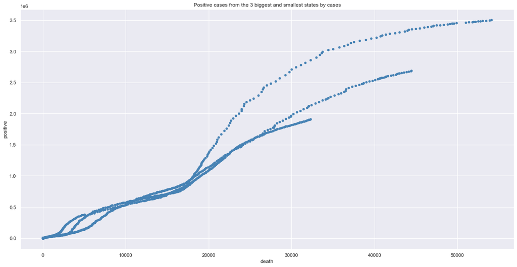

```python
data.plot(kind ="scatter", x= 'death', y ='positive', c = 'steelblue')
plt.title("Positive cases from the 3 biggest and smallest states by cases")
plt.rcParams['figure.figsize'] = [20, 10]
#plt.rcParams sets all graphs by 20:10
```

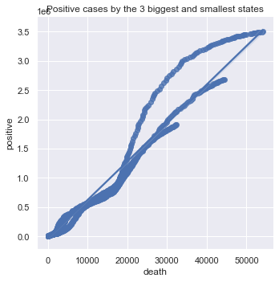

```python
sns.lmplot(x='death', y ='positive', data=data,)
plt.title("Positive cases by the 3 biggest and smallest states")
sns.set(rc={'figure.figsize':(20,10)})
#sns.set sets all graphs by 20:10
```

#### ^ The two graphs above show the correlation between the variable "death" and "positive" cases. Although it seems as though there are trendlines from the scatterplot points, it's arranging by the values that are related to each state. The second graph shows the trendline along the scatterplot showing that there is a positive correlation between death and positive cases. The graph shows that the three states with the largest count overwhelmingly shadows the three states with the smallest count. It should be noted as well that although it's not shown the scatterplot is able to expand is because of the different date entries.

[output not shown]

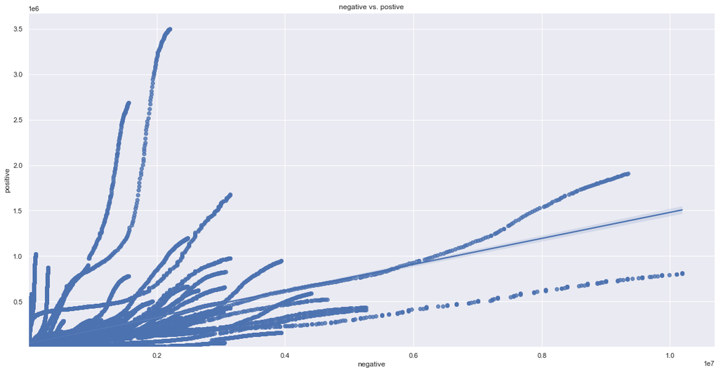

```python
g=sns.regplot(x="negative",y="positive", data=df)
g.set(xlim=80, ylim=60, title="negative vs. postive")
```

#### ^ We decided to plot against positive and negative cases with all the states under the scatterplot. Although it's hard to tell it shows that states with more positive cases have less negative cases whereas states with higher negative cases have less postive cases. The trendline in the graph shows a steady positive correlation between negative and positive cases however it should be emphasized that it doesn't reflect that a person who have a negative case will have a positive case.

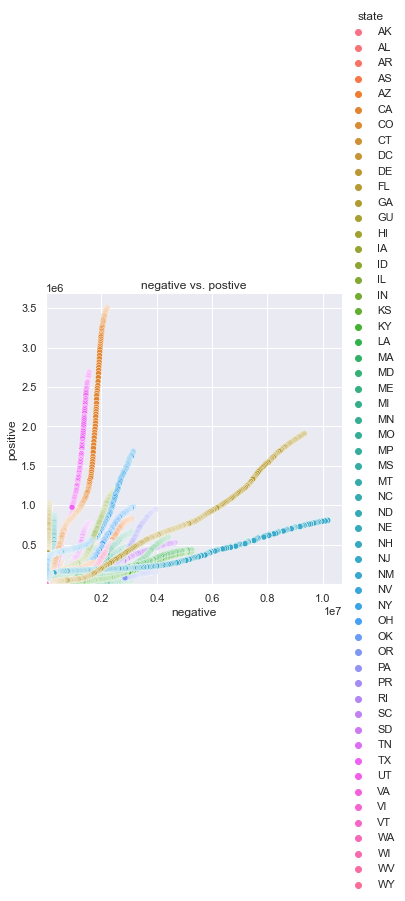

```python
g=sns.relplot(x="negative", y="positive", data=df, hue="state")
g.set(xlim=80, ylim=60, title="negative vs. postive")
# g.set(title="Age vs. Fare", xlim=[0,80], ylim=[0,600])
```

#### ^ This graph compliments with the first one as it color codes all the states by hue which makes it more identifiable. We can see that California and Texas have more positive cases than negative cases. Interestingly Florida seems to have a steady increase in both negative and positive cases.

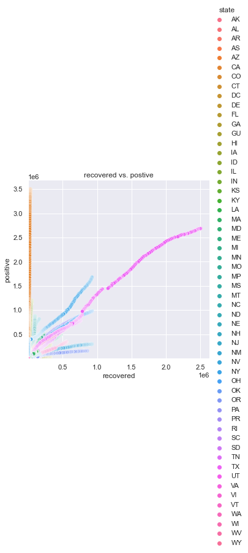

```python
g=sns.relplot(x="recovered", y="positive", data=df, hue="state")
g.set(xlim=80, ylim=60, title="recovered vs. postive")
```

#### ^ Additionally we made a scatterplot to see the relation between positive and recovered cases between the states. Unsurprisingly California still set the highest in positive cases with very low recovered cases however Texas again have a steady increase in both recovered and positive cases.

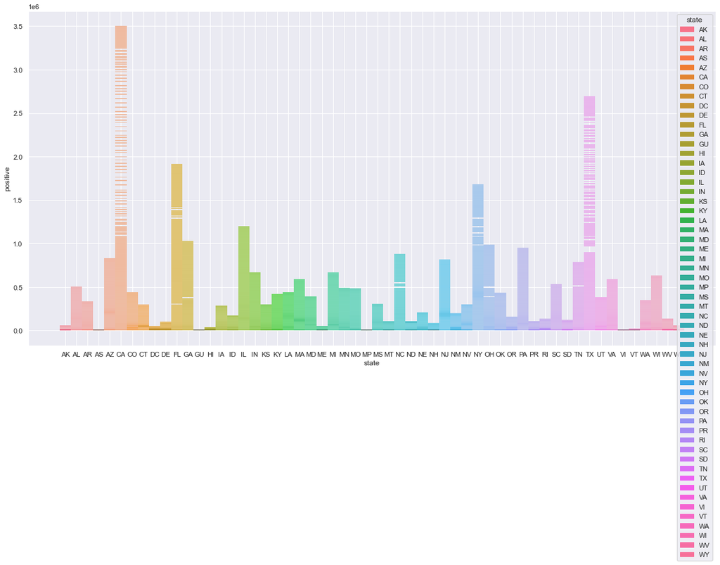

```python
#number of positive cases
import seaborn as spu
spu.histplot(data=df, x = "state", y = "positive", hue = "state")
```

#### ^ The graph above shows the all the state's number by positive cases in a histogram. We can see again the three states California, Texas and Florida having the largest numbers.

[figure not shown]

```python
#bar chart
#Creating bar plot
sns.barplot(x = 'positive',y = 'state',data = df ,palette = "rainbow")
#Adding the aesthetics
plt.title('number of cases')
plt.xlabel('hospitalized')
plt.ylabel('state')
# Show the plot
plt.show()
```

[figure not shown]

```python
plt.hist(df.loc[df["state"]=='CA', "positive"],bins=range(0,90,10),  color = 'lightgreen')
plt.hist(df.loc[df["state"]=='FL', "positive"], bins=range(0,90,10), color=  'lightblue')
plt.hist(df.loc[df["state"]=='TX', "positive"], bins=range(0,90,10), color=  'crimson')
plt.title("positive cases comparison between CA & TX")
plt.margins(x=0,y=0)
#plt.ylim([0,70])
#plt.yticks(range(0,75,10))
plt.xlim([0,80])
plt.legend(["positive cases in CA","positive cases in FL","positive cases in TX"],loc="upper left")
plt.xlabel('date')
plt.ylabel('number of positive cases (in thousands)')
plt.savefig("age.jpg")
```

## COVID-19 Vaccination Background

Fortunately we have been able to combat covid-19 with vaccinations which has saved millions of lives. Accordign to the CDC, there are 4 approved vaccines in the US. These are:

[figure not shown]

```
1. Pfizer-BioNTech COVID-19 vaccine
2. Moderna COVID-19 vaccine
3. Johnson & Johnson's Janssen COVID-19 vaccine
4. Novavax COVID-19 vaccine
```

(CDC, 2022)

As of 2022 more than 900 million doses have been released across all 50 states of the United States. The initial release of the covid-19 vaccines as well as it's protocols to mantain infection was made with backlash and negligence from the public the US. Causes of backlash stem from socieconomic to political factors however most of the public was able to catch on the severity of the pandemic's transmissive.

## III. Data Merging

We'll merge both datasdets "all-states-history.csv" and "us_state_vaccinations.csv" to make correlation interpretation of covid cases and vaccination records between the states.

```python
df1=pd.read_csv("us_state_vaccinations.csv")
```

```python
#step 1
df1=df1.rename(columns={"location":"state"})
df1
```

|  | date | state | total_vaccinations | total_distributed | people_vaccinated | people_fully_vaccinated_per_hundred | total_vaccinations_per_hundred | people_fully_vaccinated | people_vaccinated_per_hundred | distributed_per_hundred | daily_vaccinations_raw | daily_vaccinations | daily_vaccinations_per_million | share_doses_used | total_boosters | total_boosters_per_hundred |
| --- | --- | --- | --- | --- | --- | --- | --- | --- | --- | --- | --- | --- | --- | --- | --- | --- |
| 0 | 2021-01-12 | AL | 78134.0 | 377025.0 | 70861.0 | 0.15 | 1.59 | 7270.0 | 1.45 | 7.69 | NaN | NaN | NaN | 0.207 | NaN | NaN |
| 1 | 2021-01-13 | AL | 84040.0 | 378975.0 | 74792.0 | 0.19 | 1.71 | 9245.0 | 1.53 | 7.73 | 5906.0 | 5906.0 | 1205.0 | 0.222 | NaN | NaN |
| 2 | 2021-01-14 | AL | 92300.0 | 435350.0 | 80480.0 | NaN | 1.88 | NaN | 1.64 | 8.88 | 8260.0 | 7083.0 | 1445.0 | 0.212 | NaN | NaN |
| 3 | 2021-01-15 | AL | 100567.0 | 444650.0 | 86956.0 | 0.28 | 2.05 | 13488.0 | 1.77 | 9.07 | 8267.0 | 7478.0 | 1525.0 | 0.226 | NaN | NaN |
| 4 | 2021-01-16 | AL | NaN | NaN | NaN | NaN | NaN | NaN | NaN | NaN | NaN | 7498.0 | 1529.0 | NaN | NaN | NaN |
| ... | ... | ... | ... | ... | ... | ... | ... | ... | ... | ... | ... | ... | ... | ... | ... | ... |
| 47007 | 2023-01-07 | Wyoming | NaN | NaN | NaN | NaN | NaN | NaN | NaN | NaN | NaN | 167.0 | 289.0 | NaN | NaN | NaN |
| 47008 | 2023-01-08 | Wyoming | NaN | NaN | NaN | NaN | NaN | NaN | NaN | NaN | NaN | 161.0 | 278.0 | NaN | NaN | NaN |
| 47009 | 2023-01-09 | Wyoming | NaN | NaN | NaN | NaN | NaN | NaN | NaN | NaN | NaN | 155.0 | 268.0 | NaN | NaN | NaN |
| 47010 | 2023-01-10 | Wyoming | NaN | NaN | NaN | NaN | NaN | NaN | NaN | NaN | NaN | 150.0 | 259.0 | NaN | NaN | NaN |
| 47011 | 2023-01-11 | Wyoming | 847156.0 | 1246855.0 | 351894.0 | 52.97 | 146.37 | 306545.0 | 60.80 | 215.44 | NaN | 144.0 | 249.0 | 0.679 | 215704.0 | 37.27 |

47012 rows × 16 columns

#### ^In order to merge both dataset we need to find the primary key in the dataset "us_state_vaccinations". Once we've identified the key being "location" and "date", we have to rename the pk "location" to "state" so that it matches with other primary key from the dataset "all-states-history.csv" this will allow us to merge both dataset together.

```python
#step 2
df1=df1.replace({"California":"CA",
              "Texas":"TX","Arizona":"AZ","Alabama":"AL","Florida":"FL",
                "Colorado":"CO","New York":"NY","Hawaii":"HI"})
df1
```

|  | date | state | total_vaccinations | total_distributed | people_vaccinated | people_fully_vaccinated_per_hundred | total_vaccinations_per_hundred | people_fully_vaccinated | people_vaccinated_per_hundred | distributed_per_hundred | daily_vaccinations_raw | daily_vaccinations | daily_vaccinations_per_million | share_doses_used | total_boosters | total_boosters_per_hundred |
| --- | --- | --- | --- | --- | --- | --- | --- | --- | --- | --- | --- | --- | --- | --- | --- | --- |
| 0 | 2021-01-12 | AL | 78134.0 | 377025.0 | 70861.0 | 0.15 | 1.59 | 7270.0 | 1.45 | 7.69 | NaN | NaN | NaN | 0.207 | NaN | NaN |
| 1 | 2021-01-13 | AL | 84040.0 | 378975.0 | 74792.0 | 0.19 | 1.71 | 9245.0 | 1.53 | 7.73 | 5906.0 | 5906.0 | 1205.0 | 0.222 | NaN | NaN |
| 2 | 2021-01-14 | AL | 92300.0 | 435350.0 | 80480.0 | NaN | 1.88 | NaN | 1.64 | 8.88 | 8260.0 | 7083.0 | 1445.0 | 0.212 | NaN | NaN |
| 3 | 2021-01-15 | AL | 100567.0 | 444650.0 | 86956.0 | 0.28 | 2.05 | 13488.0 | 1.77 | 9.07 | 8267.0 | 7478.0 | 1525.0 | 0.226 | NaN | NaN |
| 4 | 2021-01-16 | AL | NaN | NaN | NaN | NaN | NaN | NaN | NaN | NaN | NaN | 7498.0 | 1529.0 | NaN | NaN | NaN |
| ... | ... | ... | ... | ... | ... | ... | ... | ... | ... | ... | ... | ... | ... | ... | ... | ... |
| 47007 | 2023-01-07 | Wyoming | NaN | NaN | NaN | NaN | NaN | NaN | NaN | NaN | NaN | 167.0 | 289.0 | NaN | NaN | NaN |
| 47008 | 2023-01-08 | Wyoming | NaN | NaN | NaN | NaN | NaN | NaN | NaN | NaN | NaN | 161.0 | 278.0 | NaN | NaN | NaN |
| 47009 | 2023-01-09 | Wyoming | NaN | NaN | NaN | NaN | NaN | NaN | NaN | NaN | NaN | 155.0 | 268.0 | NaN | NaN | NaN |
| 47010 | 2023-01-10 | Wyoming | NaN | NaN | NaN | NaN | NaN | NaN | NaN | NaN | NaN | 150.0 | 259.0 | NaN | NaN | NaN |
| 47011 | 2023-01-11 | Wyoming | 847156.0 | 1246855.0 | 351894.0 | 52.97 | 146.37 | 306545.0 | 60.80 | 215.44 | NaN | 144.0 | 249.0 | 0.679 | 215704.0 | 37.27 |

47012 rows × 16 columns

#### ^We then replaced the names of the entries in the state variable therefore the entries will match with the other dataset; for example "California" is now "CA".

```python
#step 3
df3=pd.merge(df, df1, on=["state", "date"])
df3
df3.drop(columns=['total_boosters', 'total_boosters_per_hundred'])
```

|  | date | state | death | deathConfirmed | deathIncrease | deathProbable | hospitalized | hospitalizedCumulative | hospitalizedCurrently | hospitalizedIncrease | ... | people_vaccinated | people_fully_vaccinated_per_hundred | total_vaccinations_per_hundred | people_fully_vaccinated | people_vaccinated_per_hundred | distributed_per_hundred | daily_vaccinations_raw | daily_vaccinations | daily_vaccinations_per_million | share_doses_used |
| --- | --- | --- | --- | --- | --- | --- | --- | --- | --- | --- | --- | --- | --- | --- | --- | --- | --- | --- | --- | --- | --- |
| 0 | 2021-03-07 | AL | 10148.0 | 7963.0 | -1 | 2185.0 | 45976.0 | 45976.0 | 494.0 | 0 | ... | 727681.0 | 8.30 | 22.64 | 406723.0 | 14.84 | 33.21 | 10435.0 | 23947.0 | 4884.0 | 0.682 |
| 1 | 2021-03-07 | AZ | 16328.0 | 14403.0 | 5 | 1925.0 | 57907.0 | 57907.0 | 963.0 | 44 | ... | 1388900.0 | 9.82 | 29.71 | 715023.0 | 19.08 | 36.05 | 118863.0 | 52879.0 | 7265.0 | 0.824 |
| 2 | 2021-03-07 | CA | 54124.0 | NaN | 258 | NaN | NaN | NaN | 4291.0 | 0 | ... | 7205989.0 | 8.47 | 26.92 | 3347266.0 | 18.24 | 35.14 | 219729.0 | 259101.0 | 6557.0 | 0.766 |
| 3 | 2021-03-07 | CO | 5989.0 | 5251.0 | 3 | 735.0 | 23904.0 | 23904.0 | 326.0 | 18 | ... | 1046640.0 | 9.86 | 28.24 | 567922.0 | 18.17 | 35.07 | 46337.0 | 36417.0 | 6324.0 | 0.805 |
| 4 | 2021-03-07 | FL | 32266.0 | NaN | 66 | NaN | 82237.0 | 82237.0 | 3307.0 | 92 | ... | 3714407.0 | 9.52 | 27.47 | 2045028.0 | 17.29 | 36.18 | 212093.0 | 122290.0 | 5694.0 | 0.759 |
| ... | ... | ... | ... | ... | ... | ... | ... | ... | ... | ... | ... | ... | ... | ... | ... | ... | ... | ... | ... | ... | ... |
| 380 | 2021-01-12 | CA | 30513.0 | NaN | 548 | NaN | NaN | NaN | 22665.0 | 0 | ... | 703540.0 | 0.25 | 2.07 | 100089.0 | 1.78 | 8.32 | NaN | NaN | NaN | 0.248 |
| 381 | 2021-01-12 | CO | 5242.0 | 4558.0 | 29 | 684.0 | 20280.0 | 20280.0 | 930.0 | 265 | ... | 187838.0 | 0.63 | 3.90 | 36425.0 | 3.26 | 8.97 | NaN | NaN | NaN | 0.434 |
| 382 | 2021-01-12 | FL | 23585.0 | NaN | 161 | NaN | 67158.0 | 67158.0 | 7720.0 | 420 | ... | 586741.0 | 0.19 | 2.95 | 41725.0 | 2.73 | 7.80 | NaN | NaN | NaN | 0.378 |
| 383 | 2021-01-12 | HI | 309.0 | 309.0 | 0 | NaN | 1902.0 | 1902.0 | 124.0 | 7 | ... | NaN | NaN | 2.36 | NaN | NaN | 10.01 | NaN | NaN | NaN | 0.236 |
| 384 | 2021-01-12 | TX | 30219.0 | NaN | 286 | NaN | NaN | NaN | 14218.0 | 0 | ... | 809148.0 | 0.35 | 3.14 | 101317.0 | 2.79 | 6.72 | NaN | NaN | NaN | 0.468 |

385 rows × 53 columns

```python
total1=(df3.groupby("state")["total_vaccinations_per_hundred"].count())
total1
```

```
state
AL    51
AZ    50
CA    51
CO    50
FL    49
HI    49
TX    49
Name: total_vaccinations_per_hundred, dtype: int64
```

[figure not shown]

```python
plt.pie(total1.values,labels=total1.index,autopct='%.0f%%')
plt.title("Total Vaccination Per Hundred")
plt.savefig("total.pdf",dpi=100)
```

[figure not shown]

```python
g=sns.lmplot(x="death",y="total_distributed",hue="state",data=df3)
g.set(xlim=0,ylim=0,title="total distribution and fully vaccinated")
```

[figure not shown]

```python
g=sns.lmplot(x="people_vaccinated_per_hundred",y="people_fully_vaccinated",hue="state",data=df3)
g.set(xlim=0, ylim=0, title="number of death")
```

#### ^This scatterplot shows the relations between people fully vaccianted against people vaccinated (per hundred). This graph is meant to show that people who are vaccinated also tend to want to be fully vaccinated as well.

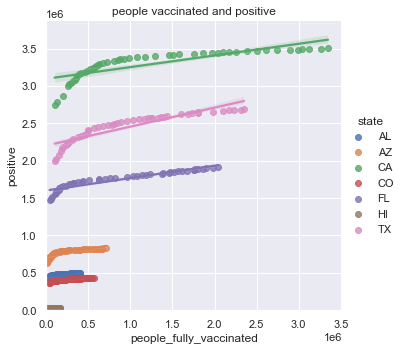

```python
g=sns.lmplot(x="people_fully_vaccinated",y="positive",hue="state",data=df3)
g.set(xlim=0,ylim=0,title="people vaccinated and positive")
```

#### ^This is another scatterplot that shows people who are vaccinated and positive but are fully vaccinated as well. Although it's hard to interprete we can see that people who are positive from covid-19 are likely as well to get vaccinated fully.

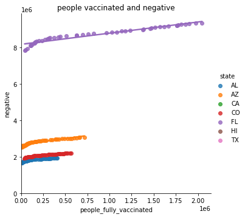

```python
g=sns.lmplot(x="people_fully_vaccinated",y="negative",hue="state",data=df3)
g.set(xlim=0,ylim=0,title="people vaccinated and negative")
```

#### ^ On the other hand this scatterplot shows people who are vaccinated and negative. This indicates that people who are tested negative still go to be fully vaccinated. We can see that Florida surprisingly has the highest count.

## Endogeneity

Our scatterplots are definitely not concretely evidental for a final conclusion of the correlation between the variables that are in the dataset to draw a clear understanding of the effects that covid-19 has on the states within the US and how the US has been combating with covid-19 vaccines. This can be drawn from the histogram where we used boolen method which in return showed missing data. Another issue was when we were cleaning the data of null values and had to use backwards filling method in addition to the command "fillna" which in certain situations can help a dataset operate better however with ours this could've led to dubplicate numbers filling in for the variable columns that have missing entries.

## Conclusion

The graphs conducted from this project also solidifies or at the least draws the connection of the US's initial response to covid-19 where the state was met with protests and backlash on the government's attempt to facilitate and mandate the pandemic hence the initial higher increase that all states experience at the start until a slower more stable increase later on.

Hopefully readers have found this research imformative and learn better on the operations used to build a simple yet insightful project using python jupyter notebook.

## References

CDC, C. for D. C. and P. (2022). Covid-19 testing: What you need to know. Centers for Disease Control and Prevention. Retrieved January 15, 2023, from https://www.cdc.gov/coronavirus/2019-ncov/symptoms-testing/testing.html#:~:text=Viral%20tests%20look%20for%20a,be%20recommended%20over%20the%20other.

WHO, W. H. O. (2023). Coronavirus disease (COVID-19). World Health Organization. Retrieved January 15, 2023, from https://www.who.int/health-topics/coronavirus#tab=tab_1

worldometer, worldometer. (2020, January 22). COVID-19 CORONAVIRUS PANDEMIC. Worldometer. Retrieved January 15, 2023, from https://www.worldometers.info/coronavirus/

Centers for Disease Control and Prevention, C. D. C. (2022, November 1). Overview of covid-19 vaccines. Centers for Disease Control and Prevention. Retrieved January 19, 2023, from https://www.cdc.gov/coronavirus/2019-ncov/vaccines/different-vaccines/overview-COVID-19-vaccines.html